# 👨‍💻 Inflation forecasting using machine learning 📊

**What is inflation?**

[figure not shown]

**Motivation of the project**

- Forecasting macroeconomic conditions such as inflation is of fundamental importance for households, businesses and governments
- With rising inflation, social inequality increases as poorer households are hit the hardest by price increases
- Traditional forecasting models using macroeconometrics techniques involves discretionary choices about data and models
- Forecasts based on expert judgement (i.e. surveys) might be based on wrong intuitions
- Can we use machine learning (ML) / deep learning (DL) techniques to predict inflation?

Pros👍

- ML/DL techniques let the data speak
- ML/DL techniques better capture non-linearities in the data
- The available literature says that forecasts from different ML/DL models generally perform better than traditional models

Cons👎

- Models are mostly not transparent ('black box')
- It is important to have a theory of how the economy works!
- ML/DL models work better on large datasets (only few years/months of data available in macro)

# Let's take a look at the data on inflation for the US

[interactive chart not shown]

What is the goal of our project?

- Train a model to predict inflation using different ML/DL techniques
- We will initially focus on the US to then then extend out project to other countries (e.g. eurozone countries)
- The data will be obtained using different python packages (essentially APIs) such as *Fred* for US data
- We will build a dashboard where the user will have the opportunity to:
  - Select a country
  - Select a time horizon
  - Obtain the inflation forecast for the selected country/time parameters
  - The model will be trained as new macroeconomic data are published

# Preliminary analysis

[interactive chart not shown]

# Monthly y-o-y inflation forecast from February 2023 until January 2025

[interactive chart not shown]

**How do we proceed?**

- We will first gather data to investigate the main determinants of inflation (features selection and features processing) 📝
- We will try different ML/DL models (e.g. RNN LSTM, XGBoost, etc.); **PS:** there are numerous studies available so we won't be lost 😉
- We will build our frontend product, i.e. the dashboard 📈
- We will put the model into "production" 😎

# Some exploratory work on the determinants of inflation..

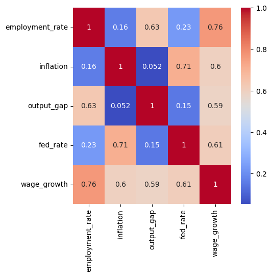

It would be great if you will consider to participate in this project!

Thanks for your attention!! 🐤